# 1. Data Rich vs Data Poor

## 10.2 Run LBSPR

```r
lbspr_algo <- Lbspr$new(bio_params, exp_params, catch_weight_data)
lbspr_results <- lbspr_algo$run()
data <- lbspr_results$estimates
data$years <- lbspr_results$years
```

```r
data
```

A data.frame: 24 × 5

| SL50 <dbl> | SL95 <dbl> | FM <dbl> | SPR <dbl> | years <int> |
| --- | --- | --- | --- | --- |
| 20.95 | 26.57 | 1.29 | 0.44 | 1999 |
| 21.92 | 27.88 | 1.36 | 0.46 | 2000 |
| 22.73 | 28.68 | 1.37 | 0.50 | 2001 |
| 24.47 | 30.99 | 1.52 | 0.49 | 2002 |
| 25.08 | 31.93 | 1.45 | 0.48 | 2003 |
| 25.71 | 32.66 | 1.44 | 0.47 | 2004 |
| 26.25 | 33.29 | 1.51 | 0.46 | 2005 |
| 27.06 | 34.17 | 1.67 | 0.44 | 2006 |
| 27.97 | 35.30 | 1.89 | 0.43 | 2007 |
| 28.21 | 35.42 | 1.93 | 0.42 | 2008 |
| 27.85 | 34.75 | 1.76 | 0.42 | 2009 |
| 27.89 | 34.68 | 1.67 | 0.42 | 2010 |
| 27.55 | 34.00 | 1.61 | 0.40 | 2011 |
| 27.63 | 34.09 | 1.57 | 0.40 | 2012 |
| 27.75 | 34.23 | 1.52 | 0.41 | 2013 |
| 27.98 | 34.62 | 1.50 | 0.41 | 2014 |
| 28.02 | 34.56 | 1.45 | 0.42 | 2015 |
| 28.08 | 34.51 | 1.45 | 0.42 | 2016 |
| 28.37 | 35.01 | 1.49 | 0.42 | 2017 |
| 28.44 | 34.88 | 1.55 | 0.42 | 2018 |
| 28.42 | 34.61 | 1.59 | 0.41 | 2019 |
| 28.45 | 34.47 | 1.67 | 0.41 | 2020 |
| 28.42 | 34.31 | 1.68 | 0.41 | 2021 |
| 28.49 | 34.30 | 1.76 | 0.40 | 2022 |

- **Along the columns** are laid the **outputs** that the algorithm has estimated
- **Each cell** for each row provides the value for a **single output per year**.

## 10.3 LBSPR plotting

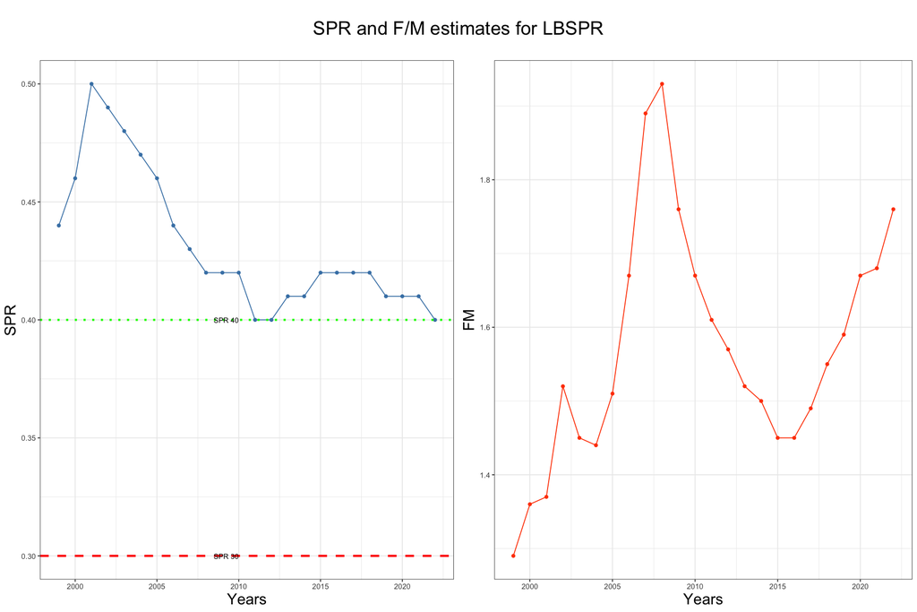

```r
options(repr.plot.width = 15, repr.plot.height = 10)
lbspr_plotter <- LbsprOutputPlotter$new(data)
grid <- lbspr_plotter$generate_outputs(title_size=22, title = "SPR and F/M estimates for LBSPR")
grid
```

- On the left, the estimated **SPR** seems to be **above 0.4** line
- Again 2001 the **highest SPR**
- On the right, the **F/M** estimates follow a **see-saw** pattern with reagards to the SPR.

## 10.3 An explanation of the outputs by looking at the length frequency distribution

[figure not shown]

- Likewise for the LBI, the year 2001 has the highest estimated SPR, while **2021 one of the lowest**.
- Again looking at the frequency distributions below, it seems that the **right thick tale for 2001** may have something to say about why the SPR value is the highest in the whole timeseries. There seems to be a substantial set of **large individuals that are rising the average length above the L50**, therefore most likely a higher contribution to the spawning biomass.
- On the other hand, given that the SPR is estimated based on the F/M, **low estimates of F/M** would yield **high estimates of SPR**.

# 11. LIME algorithm

## 11.1 Lime Overview

[figure not shown]

Lime is a fully **age-structure** length-based mixed effects model that **does not assume equilibrium**. To do so introduce the effect of the **recruitment variability as a random effect**. It also has extra parameterisation requirements:

- **M**: Natural mortality
- **SL50 and SL95**: exploitation parameters concerning the length at 50% and 95% selectivity. The mean of the **outputs of LBSPR** for selectivity are **inputted into LIME**.
- **Recruitment variability** (log-normal): to account for recruitment as a **random effect** in the outputs and **delimit** the estimated recuitment variability.
- **Fishing mortality** (log-normal): to cap the estimated inter-annual fishing mortality **avoiding** so to derail to and produce **unexpected values**.

*Lime outputs are*:

- **SPR**
- Actual inter-annual **fishing mortality** as opposed to a relative score like in LBSPR.
- **Recruitment variability**: equilibrium = 1. The maximum value allowed is twice the equilibrium (<=2).
- SPR is calculated as a function of **F**, hence the lower F the higher the **SPR** is.

*Important*:

- The **recruitment variability** prior was obtained from a meta-analysis study involving **154 species**. The mean and standard deviation in this example is the one available at **order level** instead of species-level or even better, stock-level.
- The standard deviation of fishing mortality has been set to the default one: **0.2** (log-normal)

## 11.2 Run LIME

```r
exp_params$s50 <- mean(lbspr_results$estimates$SL50)
exp_params$s95 <- mean(lbspr_results$estimates$SL95)
exp_params$sigmaF <- 0.2
lime_algo <- Lime$new(bio_params, exp_params, catch_weight_data)
lime_results <- lime_algo$run()
```

```r
data <- lime_results$estimates
data$years <- lime_results$years
data
```

A data.frame: 24 × 9

| SL50 <dbl> | SL95 <dbl> | SPR <dbl> | F <dbl> | Recruitment <dbl> | max_gradient <dbl> | hessian <lgl> | convergence <lgl> | years <int> |
| --- | --- | --- | --- | --- | --- | --- | --- | --- |
| 33.07792 | 40.79524 | 0.4682300 | 0.7549956 | 0.3763214 | 2.134293e-12 | TRUE | TRUE | 1999 |
| 33.07792 | 40.79524 | 0.5070027 | 0.6050539 | 0.6953288 | 2.134293e-12 | TRUE | TRUE | 2000 |
| 33.07792 | 40.79524 | 0.5112497 | 0.5909107 | 1.0264104 | 2.134293e-12 | TRUE | TRUE | 2001 |
| 33.07792 | 40.79524 | 0.4801454 | 0.7045254 | 1.0700896 | 2.134293e-12 | TRUE | TRUE | 2002 |
| 33.07792 | 40.79524 | 0.4735839 | 0.7317840 | 0.9502202 | 2.134293e-12 | TRUE | TRUE | 2003 |
| 33.07792 | 40.79524 | 0.4572295 | 0.8056324 | 0.6732046 | 2.134293e-12 | TRUE | TRUE | 2004 |
| 33.07792 | 40.79524 | 0.4452236 | 0.8658611 | 0.7099721 | 2.134293e-12 | TRUE | TRUE | 2005 |
| 33.07792 | 40.79524 | 0.4336046 | 0.9296885 | 0.8067454 | 2.134293e-12 | TRUE | TRUE | 2006 |
| 33.07792 | 40.79524 | 0.4197551 | 1.0138647 | 1.6088450 | 2.134293e-12 | TRUE | TRUE | 2007 |
| 33.07792 | 40.79524 | 0.4097004 | 1.0812257 | 1.2440893 | 2.134293e-12 | TRUE | TRUE | 2008 |
| 33.07792 | 40.79524 | 0.4044273 | 1.1188853 | 1.0227436 | 2.134293e-12 | TRUE | TRUE | 2009 |
| 33.07792 | 40.79524 | 0.3850498 | 1.2729559 | 1.1359815 | 2.134293e-12 | TRUE | TRUE | 2010 |
| 33.07792 | 40.79524 | 0.3878819 | 1.2487693 | 1.2143307 | 2.134293e-12 | TRUE | TRUE | 2011 |
| 33.07792 | 40.79524 | 0.3938324 | 1.1998861 | 1.3385019 | 2.134293e-12 | TRUE | TRUE | 2012 |
| 33.07792 | 40.79524 | 0.4000078 | 1.1517757 | 0.8901760 | 2.134293e-12 | TRUE | TRUE | 2013 |
| 33.07792 | 40.79524 | 0.4049413 | 1.1151398 | 1.3582575 | 2.134293e-12 | TRUE | TRUE | 2014 |
| 33.07792 | 40.79524 | 0.4025809 | 1.1324753 | 0.6611948 | 2.134293e-12 | TRUE | TRUE | 2015 |
| 33.07792 | 40.79524 | 0.4035527 | 1.1252959 | 1.3222478 | 2.134293e-12 | TRUE | TRUE | 2016 |
| 33.07792 | 40.79524 | 0.4014552 | 1.1408666 | 0.9945268 | 2.134293e-12 | TRUE | TRUE | 2017 |
| 33.07792 | 40.79524 | 0.3924713 | 1.2108432 | 0.5787236 | 2.134293e-12 | TRUE | TRUE | 2018 |
| 33.07792 | 40.79524 | 0.3797198 | 1.3201755 | 0.3312320 | 2.134293e-12 | TRUE | TRUE | 2019 |
| 33.07792 | 40.79524 | 0.3677394 | 1.4350852 | 0.5080519 | 2.134293e-12 | TRUE | TRUE | 2020 |
| 33.07792 | 40.79524 | 0.3566783 | 1.5532487 | 0.7822646 | 2.134293e-12 | TRUE | TRUE | 2021 |
| 33.07792 | 40.79524 | 0.3566783 | 1.5532487 | 0.8539276 | 2.134293e-12 | TRUE | TRUE | 2022 |

- **Along the columns** are laid the **outputs** that the algorithm has estimated
- **Each cell** for each row provides the value for a **single output per year**.

## 11.3 LIME plotting

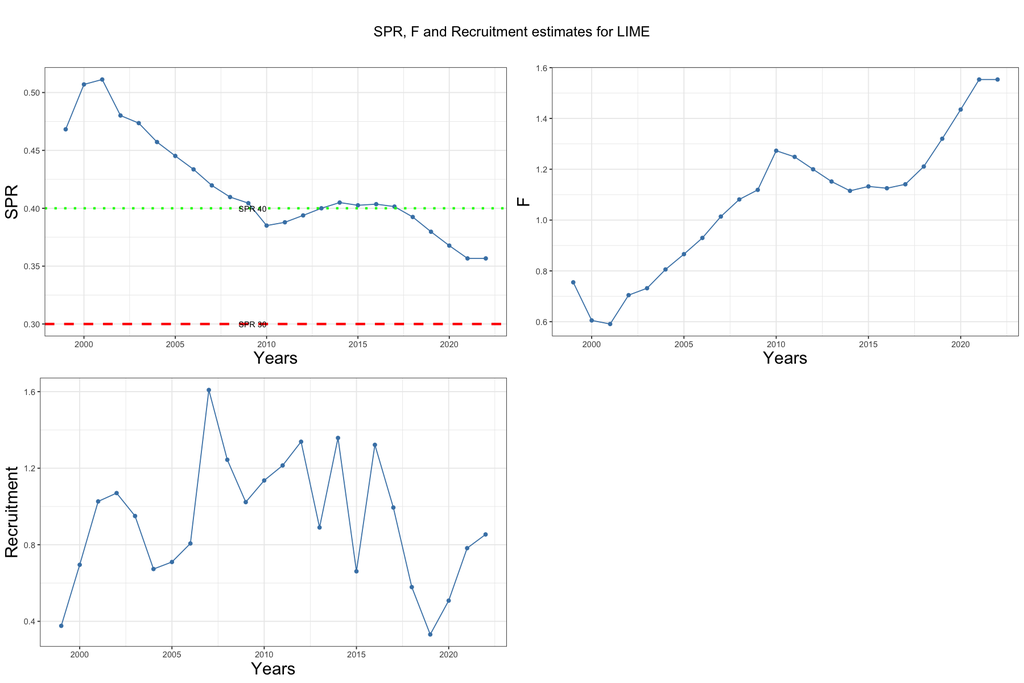

```r
options(repr.plot.width = 15, repr.plot.height = 10)
lime_plotter <- LimeOutputPlotter$new(data)
grid <- lime_plotter$generate_outputs(title_size=22, title = "SPR, F and Recruitment estimates for LIME")
grid
```

- On the top left, the estimated **SPR** is **no longer above 0.4** line all the time. LIME seems to be a little bit more pesimist.
- Again 2001 the **highest SPR**
- On the top right, the **F** estimates follow a **see-saw** pattern with reagards to the SPR.
- **Hard to interpret the recruitment variability** without knowing more about the biology of the species. For example, what's the lag that a recruitment for the fisheries could become a recruitment for spawning biomass.

# 12. LBI, LBSPR and LIME outputs combined

[figure not shown]

- It seems that LBI, LBSPR AND LIME **agree** that when **SPR** is the highest, roughly so occurs for the **adult consesrvation**.
- However LBI nonetheless, issues a **warning** about the **juvenile conservation** in the first years of the tiemseries even though with high SPR scores.
- **Selectivy** for LIME is estimated as **constant** while for LBSPR is **interannual**.
- **F/M** has been mulitplied by M so that LBSPR's output can be converted to the **domain** of fishing mortality **(F)**.